# PML Training

Hernan L. Medina

December 11, 2016

## PML Training

This exercise uses data and findings from Velloso, E.; Bulling, A.; Gellersen, H.; Ugulino, W.; Fuks, H. “Qualitative Activity Recognition of Weight Lifting Exercises.”" Proceedings of 4th International Conference in Cooperation with SIGCHI (Augmented Human ’13). Stuttgart, Germany: ACM SIGCHI, 2013. The paper can be found here http://groupware.les.inf.puc-rio.br/public/papers/2013.Velloso.QAR-WLE.pdf. The data are licensed under the Creative Commons license (CC BY-SA). The question addressed is whether or not a model can be trained to detect when a person is performing an exercise correctly or incorrectly. Five categories were defined as follows:

- A = exercise performed exactly as specified
- B = throwing the elbows to the front
- C = lifting the dumbbell only halfway
- D = lowering the dumbbell only halfway
- E = throwing the hips to the front

## Read Training Data

The following code chunk loads the packages used in this analysis, and reads the data. The file had row names with a blank column name. The read_csv function give a warning and names it X1. Additionally, messages show some variables such as (x, y, z) components were read as integer. These will be converted to numeric prior to calculating features such as skewness and kurtosis. Warnings and messages have been omitted in this document, for brevity.

```r
library(readr)
library(dplyr)
library(caret)
library(randomForest)
library(e1071)
pmltrain <- read_csv("http://d396qusza40orc.cloudfront.net/predmachlearn/pml-training.csv"
         ,na = c("NA","","#DIV/0!"), guess_max = 10000)
```

## Explore Training Data and Calculate Features

The original data set contained about one hundred variables that were largely missing. These were calculations such as minimum, maximum, variance, skewness and kurtosis of the variables captured by the devices on the belt, arm, forearm and dumbbell sensors. The following code chunk shows the dimensions of the original data set, determines which variables had missing values, creates a training data set containing only variables completely filled, shows the dimensions of the training data, converts variables read as integer to numeric, calculates features for modeling, and plots some variables to examine their relationship with the response variable. code and results other than plots have been hidden for brevity.

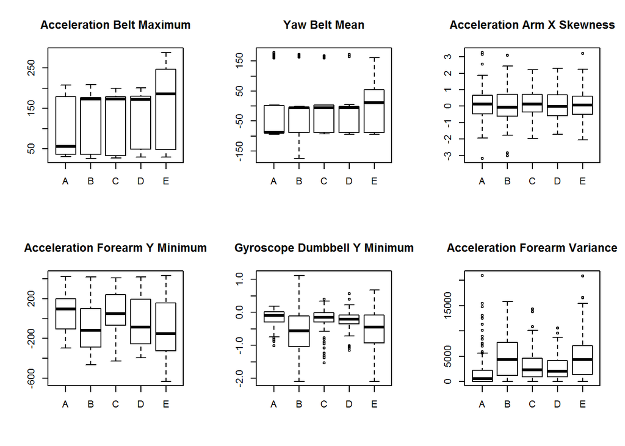

## Search An Efficient Number of Predictors

```r
set.seed(819)
predictors <- dplyr::select(training, -classe, -num_window)
response <- training$classe
m1 <- rfcv(predictors, response, cv.fold=3, ntree=30)
m1$n.var; round(m1$error.cv, digits=7)
```

```
## [1] 450 225 112  56  28  14   7   4   1
```

```
##       450       225       112        56        28        14         7
## 0.0001019 0.0001019 0.0001019 0.0001019 0.0001019 0.0001019 0.0001019
##         4         1
## 0.0003568 0.1228848
```

## Determine the most important predictors

The following code chunk uses the caret package to perform random forest with cross validation to determine the most important predictors. The first section determines importance using all the predictors, using verbose iteration to be able to track progress. The next step selects the 14 most important predictors based on Mean Decrease Accuracy of the final model. Finally, I refit the random forest using only those 14 predictors.

```r
set.seed(819)
predictors <- dplyr::select(training, -classe, -num_window)
response <- training$classe
tc <- trainControl(method = "cv", number=3, verboseIter=TRUE, savePredictions = 'final')
m2 <- train(predictors, response, method='rf', trControl=tc, ntree=30, importance=TRUE)
summary(m2)
```

```
##                 Length Class      Mode
## call                6  -none-     call
## type                1  -none-     character
## predicted       19620  factor     numeric
## err.rate          180  -none-     numeric
## confusion          30  -none-     numeric
## votes           98100  matrix     numeric
## oob.times       19620  -none-     numeric
## classes             5  -none-     character
## importance       3150  -none-     numeric
## importanceSD     2700  -none-     numeric
## localImportance     0  -none-     NULL
## proximity           0  -none-     NULL
## ntree               1  -none-     numeric
## mtry                1  -none-     numeric
## forest             14  -none-     list
## y               19620  factor     numeric
## test                0  -none-     NULL
## inbag               0  -none-     NULL
## xNames            450  -none-     character
## problemType         1  -none-     character
## tuneValue           1  data.frame list
## obsLevels           5  -none-     character
```

```r
confusionMatrix(m2)
```

```
## Cross-Validated (3 fold) Confusion Matrix
##
## (entries are percentual average cell counts across resamples)
##
##           Reference
## Prediction    A    B    C    D    E
##          A 28.4  0.0  0.0  0.0  0.0
##          B  0.0 19.3  0.0  0.0  0.0
##          C  0.0  0.0 17.4  0.0  0.0
##          D  0.0  0.0  0.0 16.4  0.0
##          E  0.0  0.0  0.0  0.0 18.4
##
##  Accuracy (average) : 0.9999
```

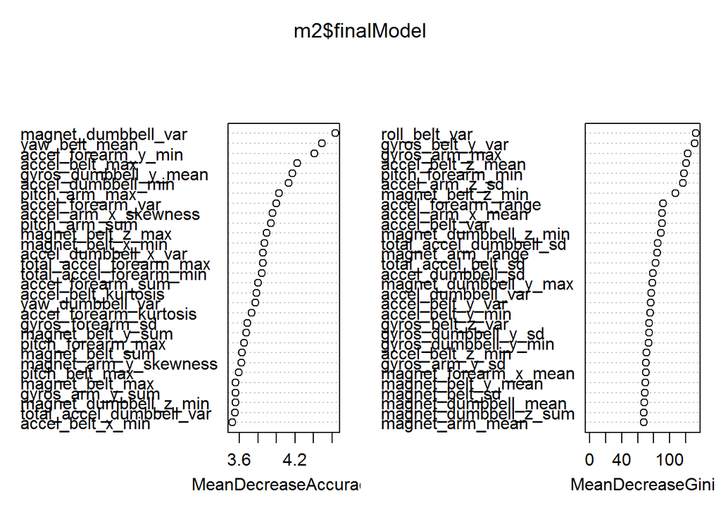

```r
varImpPlot(m2$finalModel)
```

```r
im2 <- data.frame(importance(m2$finalModel))
ndx <- im2$MeanDecreaseAccuracy > 3.85
imp_names <- row.names(im2[ndx,])
predictors <- training[, imp_names]
set.seed(819)
tc <- trainControl(method = "cv", number=3, verboseIter=TRUE, savePredictions = 'final')
m3 <- train(predictors, response, method='rf', trControl=tc, ntree=30, importance=TRUE)
summary(m3)
```

```
##                 Length Class      Mode
## call                6  -none-     call
## type                1  -none-     character
## predicted       19620  factor     numeric
## err.rate          180  -none-     numeric
## confusion          30  -none-     numeric
## votes           98100  matrix     numeric
## oob.times       19620  -none-     numeric
## classes             5  -none-     character
## importance         98  -none-     numeric
## importanceSD       84  -none-     numeric
## localImportance     0  -none-     NULL
## proximity           0  -none-     NULL
## ntree               1  -none-     numeric
## mtry                1  -none-     numeric
## forest             14  -none-     list
## y               19620  factor     numeric
## test                0  -none-     NULL
## inbag               0  -none-     NULL
## xNames             14  -none-     character
## problemType         1  -none-     character
## tuneValue           1  data.frame list
## obsLevels           5  -none-     character
```

```r
confusionMatrix(m3)
```

```
## Cross-Validated (3 fold) Confusion Matrix
##
## (entries are percentual average cell counts across resamples)
##
##           Reference
## Prediction    A    B    C    D    E
##          A 28.4  0.0  0.0  0.0  0.0
##          B  0.0 19.3  0.0  0.0  0.0
##          C  0.0  0.0 17.4  0.0  0.0
##          D  0.0  0.0  0.0 16.4  0.0
##          E  0.0  0.0  0.0  0.0 18.4
##
##  Accuracy (average) : 1
```

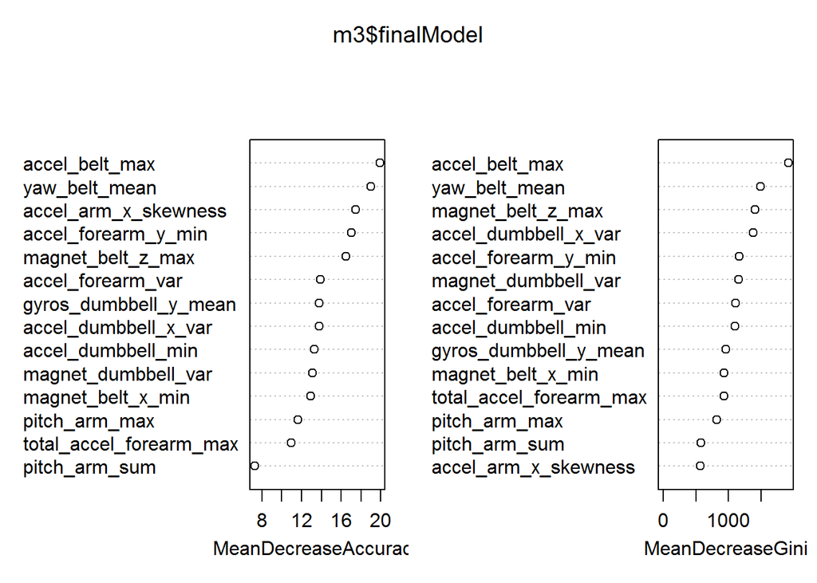

```r
varImpPlot(m3$finalModel)
```

## Predict Results for Testing Data

```r
pmltest <- read_csv("http://d396qusza40orc.cloudfront.net/predmachlearn/pml-testing.csv"
                     ,na = c("NA","","#DIV/0!"))
testing <- inner_join(select(pmltest, num_window, problem_id), t, by='num_window')
predictors <- data.frame(testing[, imp_names], testing$problem_id)
predicted <- predict(m3, newdata=predictors)
answers <- data.frame(testing$problem_id, predicted)
```